# California Housing Price Prediction: Moving Beyond Linearity

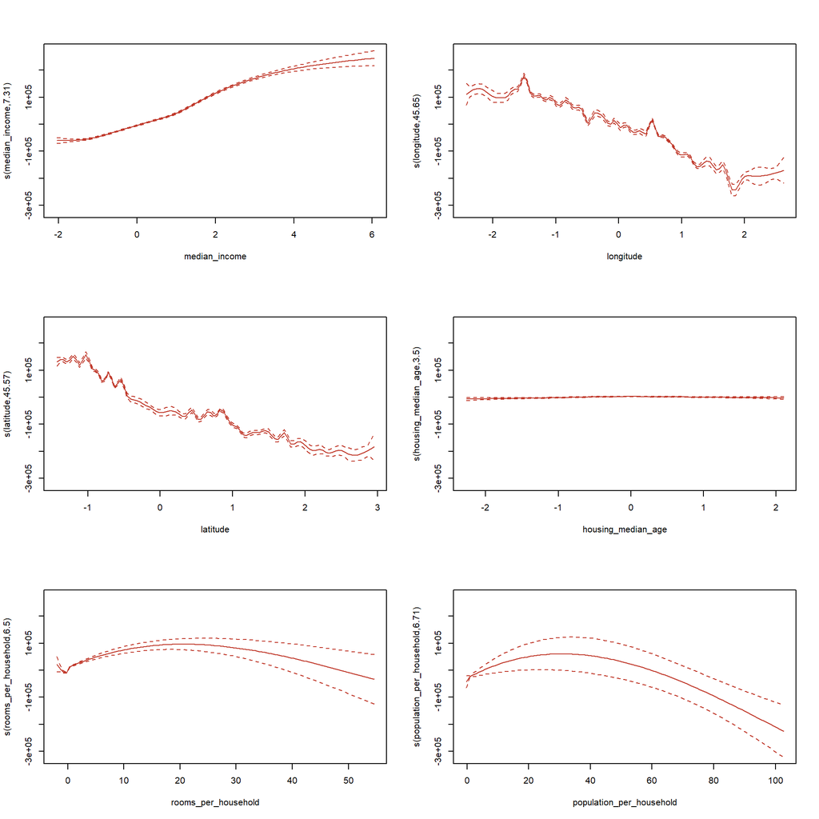

```r
par(mfrow = c(3, 2)) # 3x2 grid perfectly fits our 6 independent 1D variables

# Because everything is 1D now, we can apply the shading to all of them at once!
plot(ss_multi,
     pages = 0,
     shade = TRUE,
     col = "#c0392b",
     shade.col = "#f5c6c6",
     seWithMean = TRUE)
```

```r
par(mfrow = c(1, 1))
```

**Interpretations and Discussions**  
1. `median_income` -> As the median income increased (right of the x-axis), this showed that the house price also increased (increasing y-axis).  
2. `housing_median_age` -> Once location and income are factored in, the median age of a house has relatively low effect to the house prices.  
3. `rooms_per_household` -> The confidence intervals flared toward the right. This showed that at extreme values it was not a major driver of house prices.  
4. `population_per_household` -> As the population increased, it started as a positive house price but in the long run became negative. This showed us that, overcrowded households tend to be in cheaper neighbourhoods where the house proce is cheaper.  
5. `longitude`,`latitude` -> Modeled strictly as independent 1D variables, the curves show massive fluctuations. The model attempted to draw lines matching the peaks and valleys of California’s geography (e.g., coastal vs. inland prices) independently from east-to-west and north-to-south. However, separating these coordinates failed to capture the true 2D nature of a map.

We explored the true multi-dimensional topographical map (combining latitude and longitude) in our upcoming GAM Tensor model (Model 7)

# 8 Model 6 — Local Regression (LOESS)

**Theoretical basis:** Local regression fits weighted least-squares models in a moving neighbourhood of each point. The span parameter $\alpha$ controls the neighbourhood width, analogous to $\lambda$ in smoothing splines.

$$\hat{f}(x_0) = \arg\min_{\beta}
\sum_{i=1}^{n} K\!\left(\frac{x_i - x_0}{h}\right)(y_i - \beta_0 -
\beta_1 x_i)^2$$

```r
# Illustrative 1D LOESS: income vs house value
loess_1d <- loess(
  median_house_value ~ median_income,
  data = train_sc, span = 0.25, degree = 2
)

summary(loess_1d)
```

```
#> Call:
#> loess(formula = median_house_value ~ median_income, data = train_sc,
#>     span = 0.25, degree = 2)
#>
#> Number of Observations: 14845
#> Equivalent Number of Parameters: 13.6
#> Residual Standard Error: 70850
#> Trace of smoother matrix: 15.03  (exact)
#>
#> Control settings:
#>   span     :  0.25
#>   degree   :  2
#>   family   :  gaussian
#>   surface  :  interpolate      cell = 0.2
#>   normalize:  TRUE
#>  parametric:  FALSE
#> drop.square:  FALSE
```

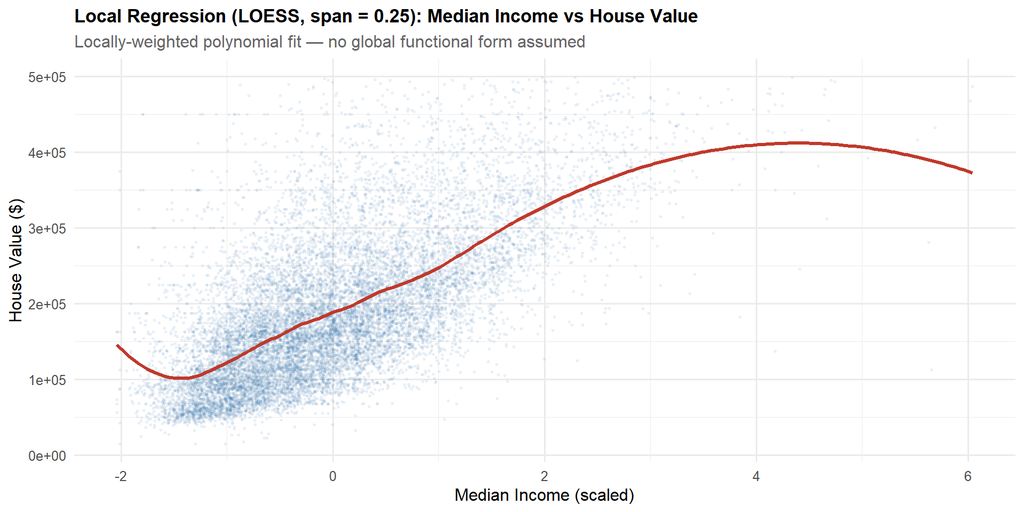

```r
loess_grid <- data.frame(median_income = seq(
  min(train_sc$median_income), max(train_sc$median_income), length = 200))
loess_grid$fit <- predict(loess_1d, newdata = loess_grid)

ggplot(train_sc, aes(x = median_income, y = median_house_value)) +
  geom_point(alpha = 0.06, color = "#2e6da4", size = 0.5) +
  geom_line(data = loess_grid, aes(y = fit), color = "#c0392b", linewidth = 1.2) +
  labs(
    title    = "Local Regression (LOESS, span = 0.25): Median Income vs House Value",
    subtitle = "Locally-weighted polynomial fit — no global functional form assumed",
    x = "Median Income (scaled)", y = "House Value ($)"
  )
```

```r
# Predict and Track Metrics (Model 6a)
# Predict on the actual test set
loess_1d_pred <- predict(loess_1d, newdata = test_sc)

# Safety Net: LOESS returns NA for out-of-bounds test points
if(any(is.na(loess_1d_pred))) {
  warning("LOESS 1D produced NAs for out-of-bounds predictions. Imputing with mean.")
  loess_1d_pred[is.na(loess_1d_pred)] <- mean(train_sc$median_house_value, na.rm = TRUE)
}

# Calculate and store metrics
loess_1d_metrics <- calc_metrics(actual = y_test, predicted = loess_1d_pred, model_name = "6a. Single LOESS (Income)")
all_metrics[["LOESS_1D"]] <- loess_1d_metrics
all_preds[["LOESS_1D"]] <- loess_1d_pred


print(loess_1d_metrics)
```

```
#> # A tibble: 1 × 4
#>   Model                       RMSE    MAE    R2
#>   <chr>                      <dbl>  <dbl> <dbl>
#> 1 6a. Single LOESS (Income) 70879. 53969. 0.455
```

We then constructed a multivariate LOESS model:

```r
# Multivariate LOESS (Strictly pure LOESS, max 4 predictors)
# Note: Base R's loess() mathematically restricts us to a maximum of 4 predictors
# due to the curse of dimensionality in local regression. We use the top 4.
loess_multi <- loess(
  median_house_value ~ median_income + longitude + latitude + housing_median_age,
  data = train_sc,
  span = 0.10, # A small span is needed for 4D space
  control = loess.control(surface = "interpolate")
)

# Print the basic LOESS summary
summary(loess_multi)
```

```
#> Call:
#> loess(formula = median_house_value ~ median_income + longitude +
#>     latitude + housing_median_age, data = train_sc, span = 0.1,
#>     control = loess.control(surface = "interpolate"))
#>
#> Number of Observations: 14845
#> Equivalent Number of Parameters: 117.3
#> Residual Standard Error: 134600
#> Trace of smoother matrix: 150.87  (exact)
#>
#> Control settings:
#>   span     :  0.1
#>   degree   :  2
#>   family   :  gaussian
#>   surface  :  interpolate      cell = 0.2
#>   normalize:  TRUE
#>  parametric:  FALSE FALSE FALSE FALSE
#> drop.square:  FALSE FALSE FALSE FALSE
```

```r
# Predict and Track Metrics (Model 6b)
loess_multi_pred <- predict(loess_multi, newdata = test_sc)

# Safety Net: Standard LOESS often returns NA for test points slightly outside
# the training boundaries. We impute any NAs with the mean house value.
if(any(is.na(loess_multi_pred))) {
  warning("LOESS produced NAs for out-of-bounds predictions. Imputing with mean.")
  loess_multi_pred[is.na(loess_multi_pred)] <- mean(train_sc$median_house_value, na.rm = TRUE)
}

# Calculate and store metrics
loess_multi_metrics <- calc_metrics(actual = y_test, predicted = loess_multi_pred, model_name = "6b. Multivariate LOESS (4 Predictors)")
all_metrics[["LOESS_Multi"]] <- loess_multi_metrics
all_preds[["LOESS_Multi"]] <- loess_multi_pred

# Print the official results
print(loess_multi_metrics)
```

```
#> # A tibble: 1 × 4
#>   Model                                    RMSE    MAE    R2
#>   <chr>                                   <dbl>  <dbl> <dbl>
#> 1 6b. Multivariate LOESS (4 Predictors) 135711. 88947. 0.141
```

This multidimensional limitation perfectly highlighted why standard LOESS is insufficient for modern, wide datasets, and why GAMs are the superior fit for our California housing data. GAMs brilliantly bypass the Curse of Dimensionality by treating variables additively. Instead of forcing all variables into one massive, sparse multidimensional window, a GAM calculates separate, flexible 1D or 2D smooth curves for each feature and simply adds them together. This additive framework would finally allow us to model non-linear relationships across all our variables simultaneously without breaking the laws of spatial mathematics.

# 9 Model 7 — Generalized Additive Model (GAM)

**Theoretical basis:** GAMs replace linear predictors with flexible smooth functions while maintaining additivity:

$$y_i = \beta_0 + \sum_{j=1}^{p}
f_j(x_{ij}) + \varepsilon_i$$

We extend this with **tensor product interaction terms** `ti()` to capture the income × location interaction that an additive model would otherwise miss.

```r
gam_model <- mgcv::gam(
  median_house_value ~
    s(median_income) +
    s(latitude) +
    s(longitude) +
    s(housing_median_age) +
    s(rooms_per_household) +
    s(population_per_household) +
    s(bedrooms_per_room) +
    ti(latitude, longitude) +          # Spatial interaction term (2D Geography)
    ti(median_income, latitude),         # Income × location interaction
  data   = train_sc,
  method = "REML"
)

# Print the summary to inspect the significance of the tensor interactions
summary(gam_model)
```

```
#>
#> Family: gaussian
#> Link function: identity
#>
#> Formula:
#> median_house_value ~ s(median_income) + s(latitude) + s(longitude) +
#>     s(housing_median_age) + s(rooms_per_household) + s(population_per_household) +
#>     s(bedrooms_per_room) + ti(latitude, longitude) + ti(median_income,
#>     latitude)
#>
#> Parametric coefficients:
#>             Estimate Std. Error t value Pr(>|t|)
#> (Intercept)   188285      28255   6.664 2.76e-11 ***
#> ---
#> Signif. codes:  0 '***' 0.001 '**' 0.01 '*' 0.05 '.' 0.1 ' ' 1
#>
#> Approximate significance of smooth terms:
#>                                edf Ref.df       F  p-value
#> s(median_income)             7.900  8.693 331.544  < 2e-16 ***
#> s(latitude)                  8.445  8.784  38.033  < 2e-16 ***
#> s(longitude)                 8.602  8.797  52.757  < 2e-16 ***
#> s(housing_median_age)        3.318  4.137   5.119 0.000372 ***
#> s(rooms_per_household)       8.164  8.756  16.118  < 2e-16 ***
#> s(population_per_household)  8.793  8.984 340.813  < 2e-16 ***
#> s(bedrooms_per_room)         6.132  7.348   5.177 4.06e-06 ***
#> ti(latitude,longitude)      12.515 13.049  85.188  < 2e-16 ***
#> ti(median_income,latitude)   8.627 10.342   7.094  < 2e-16 ***
#> ---
#> Signif. codes:  0 '***' 0.001 '**' 0.01 '*' 0.05 '.' 0.1 ' ' 1
#>
#> R-sq.(adj) =  0.717   Deviance explained = 71.8%
#> -REML = 1.8194e+05  Scale est. = 2.5643e+09  n = 14845
```

```r
# Predict and Track Metrics (Model 7)
# Predict on the test set
gam_pred <- predict(gam_model, newdata = test_sc)

# Calculate and store metrics
gam_metrics <- calc_metrics(actual = y_test, predicted = gam_pred, model_name = "7. Generalized Additive Model (GAM)")
all_metrics[["GAM"]] <- gam_metrics
all_preds[["GAM"]] <- gam_pred

# Print the official results!
print(gam_metrics)
```

```
#> # A tibble: 1 × 4
#>   Model                                 RMSE    MAE    R2
#>   <chr>                                <dbl>  <dbl> <dbl>
#> 1 7. Generalized Additive Model (GAM) 50236. 36407. 0.726
```

To visualize this complex spatial relationship, we extracted the ti(latitude, longitude) tensor product to generate a 3D topographical perspective plot. The resulting surface map beautifully illustrates the “coastal premium,” showing dramatic spikes in the isolated effect on price exactly where the major coastal tech hubs and metropolitan areas are located.

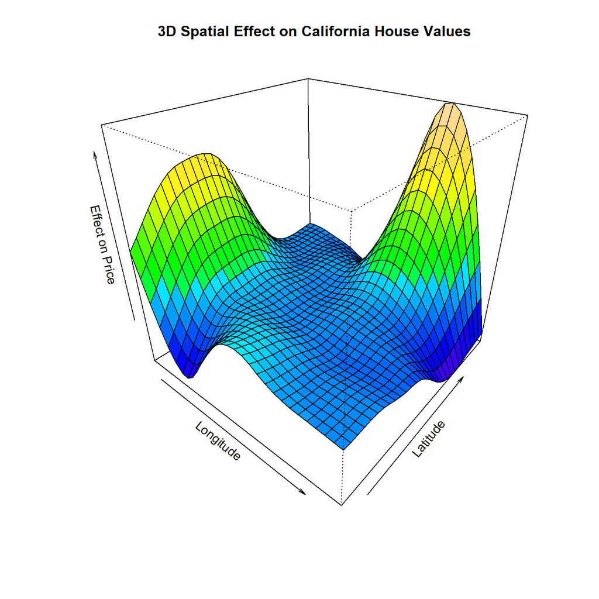

```r
# 3D perspective topographical map of the geographic interaction
mgcv::vis.gam(gam_model,
              view = c("longitude", "latitude"), # The two variables to fuse
              plot.type = "persp",               # Perspective (3D) rather than contour (2D)
              theta = 40,                        # Left/Right rotation angle
              phi = 30,                          # Up/Down tilt angle
              color = "topo",                    # Uses a topographical color palette
              main = "3D Spatial Effect on California House Values",
              zlab = "Effect on Price",
              xlab = "Longitude",
              ylab = "Latitude")
```

Our GAM tensor product (ti(latitude, longitude)) successfully mapped the highly non-linear, topographical reality of the California real estate market. The resulting surface revealed two massive geographical “peaks” (the yellow/orange regions) which perfectly corresponded to the San Francisco Bay Area and the Los Angeles/San Diego metropolitan areas. The deep blue valleys represent the significant drop in housing prices as one moves inland toward the Central Valley and desert regions. This confirms that the geographic premium on California housing is not a simple linear coastal trend, but highly localized around two specific economic epicenters.

We proceeded to tack the tree based models and we began with Random Forest.